# Employee Attrition

XYZ

2022-11-15

## R Markdown

#### **Question-1: State the dataset you will use in your project. Explain what this is about.**

#### **The dataset I selected in my project is “Employee Attrition” dataset of a Hospital. The objective of this data investigation and analysis is to determine the company’s attrition rate. Using descriptive statistics and graphical methods, the dataset will be interpreted.**

```r
df <- read.csv("Employee_dataset.csv", header = TRUE)
```

#### **In this dataset, There are 1676 rows and 35 columns. I list the names and types of the columns and first 6 and last 6 rows of the dataset below.**

```
##  ï..EmployeeID          Age         Attrition         BusinessTravel
##  Min.   :1025177   Min.   :18.00   Length:1676        Length:1676
##  1st Qu.:1235832   1st Qu.:30.00   Class :character   Class :character
##  Median :1464606   Median :36.00   Mode  :character   Mode  :character
##  Mean   :1456796   Mean   :36.87
##  3rd Qu.:1667992   3rd Qu.:43.00
##  Max.   :1886378   Max.   :60.00
##    DailyRate       Department        DistanceFromHome   Education
##  Min.   : 102.0   Length:1676        Min.   : 1.000   Min.   :1.000
##  1st Qu.: 465.0   Class :character   1st Qu.: 2.000   1st Qu.:2.000
##  Median : 796.5   Mode  :character   Median : 7.000   Median :3.000
##  Mean   : 800.6                      Mean   : 9.222   Mean   :2.908
##  3rd Qu.:1157.0                      3rd Qu.:14.000   3rd Qu.:4.000
##  Max.   :1499.0                      Max.   :29.000   Max.   :5.000
##  EducationField     EmployeeCount EnvironmentSatisfaction    Gender
##  Length:1676        Min.   :1     Min.   :1.000           Length:1676
##  Class :character   1st Qu.:1     1st Qu.:2.000           Class :character
##  Mode  :character   Median :1     Median :3.000           Mode  :character
##                     Mean   :1     Mean   :2.715
##                     3rd Qu.:1     3rd Qu.:4.000
##                     Max.   :1     Max.   :4.000
##    HourlyRate     JobInvolvement     JobLevel       JobRole
##  Min.   : 30.00   Min.   :1.000   Min.   :1.000   Length:1676
##  1st Qu.: 48.00   1st Qu.:2.000   1st Qu.:1.000   Class :character
##  Median : 65.50   Median :3.000   Median :2.000   Mode  :character
##  Mean   : 65.47   Mean   :2.725   Mean   :2.067
##  3rd Qu.: 83.00   3rd Qu.:3.000   3rd Qu.:3.000
##  Max.   :100.00   Max.   :4.000   Max.   :5.000
##  JobSatisfaction MaritalStatus      MonthlyIncome    MonthlyRate
##  Min.   :1.000   Length:1676        Min.   : 1009   Min.   : 2094
##  1st Qu.:2.000   Class :character   1st Qu.: 2928   1st Qu.: 7993
##  Median :3.000   Mode  :character   Median : 4899   Median :14270
##  Mean   :2.739                      Mean   : 6517   Mean   :14287
##  3rd Qu.:4.000                      3rd Qu.: 8380   3rd Qu.:20462
##  Max.   :4.000                      Max.   :19999   Max.   :26999
##  NumCompaniesWorked    Over18            OverTime         PercentSalaryHike
##  Min.   :0.000      Length:1676        Length:1676        Min.   :11.0
##  1st Qu.:1.000      Class :character   Class :character   1st Qu.:12.0
##  Median :2.000      Mode  :character   Mode  :character   Median :14.0
##  Mean   :2.662                                            Mean   :15.2
```

[output cut: 8 more lines]

```
##  Max.   :4.00      Max.   :4.000            Max.   :80    Max.   :3.0000
##  TotalWorkingYears TrainingTimesLastYear WorkLifeBalance YearsAtCompany
##  Min.   : 0.00     Min.   :0.000         Min.   :1.000   Min.   : 0.000
##  1st Qu.: 6.00     1st Qu.:2.000         1st Qu.:2.000   1st Qu.: 3.000
##  Median :10.00     Median :3.000         Median :3.000   Median : 5.000
##  Mean   :11.34     Mean   :2.805         Mean   :2.766   Mean   : 7.033
##  3rd Qu.:15.00     3rd Qu.:3.000         3rd Qu.:3.000   3rd Qu.:10.000
##  Max.   :40.00     Max.   :6.000         Max.   :4.000   Max.   :40.000
##  YearsInCurrentRole YearsSinceLastPromotion YearsWithCurrManager
##  Min.   : 0.000     Min.   : 0.0            Min.   : 0.000
##  1st Qu.: 2.000     1st Qu.: 0.0            1st Qu.: 2.000
##  Median : 3.000     Median : 1.0            Median : 3.000
##  Mean   : 4.265     Mean   : 2.2            Mean   : 4.135
##  3rd Qu.: 7.000     3rd Qu.: 3.0            3rd Qu.: 7.000
##  Max.   :18.000     Max.   :15.0            Max.   :17.000
```

```
## 'data.frame':    1676 obs. of  35 variables:
##  $ ï..EmployeeID           : int  1313919 1200302 1060315 1272912 1414939 1633361 1329390 1699288 1469740 1101291 ...
##  $ Age                     : int  41 49 37 33 27 32 59 30 38 36 ...
##  $ Attrition               : chr  "No" "No" "Yes" "No" ...
##  $ BusinessTravel          : chr  "Travel_Rarely" "Travel_Frequently" "Travel_Rarely" "Travel_Frequently" ...
##  $ DailyRate               : int  1102 279 1373 1392 591 1005 1324 1358 216 1299 ...
##  $ Department              : chr  "Cardiology" "Maternity" "Maternity" "Maternity" ...
##  $ DistanceFromHome        : int  1 8 2 3 2 2 3 24 23 27 ...
##  $ Education               : int  2 1 2 4 1 2 3 1 3 3 ...
##  $ EducationField          : chr  "Life Sciences" "Life Sciences" "Other" "Life Sciences" ...
##  $ EmployeeCount           : int  1 1 1 1 1 1 1 1 1 1 ...
##  $ EnvironmentSatisfaction : int  2 3 4 4 1 4 3 4 4 3 ...
##  $ Gender                  : chr  "Female" "Male" "Male" "Female" ...
##  $ HourlyRate              : int  94 61 92 56 40 79 81 67 44 94 ...
##  $ JobInvolvement          : int  3 2 2 3 3 3 4 3 2 3 ...
```

[output cut: 21 more lines]

```
##   ï..EmployeeID Age Attrition    BusinessTravel DailyRate Department
## 1       1313919  41        No     Travel_Rarely      1102 Cardiology
## 2       1200302  49        No Travel_Frequently       279  Maternity
## 3       1060315  37       Yes     Travel_Rarely      1373  Maternity
## 4       1272912  33        No Travel_Frequently      1392  Maternity
## 5       1414939  27        No     Travel_Rarely       591  Maternity
## 6       1633361  32        No Travel_Frequently      1005  Maternity
##   DistanceFromHome Education EducationField EmployeeCount
## 1                1         2  Life Sciences             1
## 2                8         1  Life Sciences             1
## 3                2         2          Other             1
## 4                3         4  Life Sciences             1
## 5                2         1        Medical             1
## 6                2         2  Life Sciences             1
##   EnvironmentSatisfaction Gender HourlyRate JobInvolvement JobLevel JobRole
```

[output cut: 41 more lines]

```
##      ï..EmployeeID Age Attrition BusinessTravel DailyRate Department
## 1671       1336016  28       Yes  Travel_Rarely       654  Maternity
## 1672       1117656  26       Yes  Travel_Rarely       471  Neurology
## 1673       1152327  46        No  Travel_Rarely      1125 Cardiology
## 1674       1812428  20        No  Travel_Rarely       959  Maternity
## 1675       1812429  39        No  Travel_Rarely       466  Neurology
## 1676       1152329  27        No  Travel_Rarely       511 Cardiology
##      DistanceFromHome Education   EducationField EmployeeCount
## 1671                1         2    Life Sciences             1
## 1672               24         3 Technical Degree             1
## 1673               10         3        Marketing             1
## 1674                1         3    Life Sciences             1
## 1675                1         1    Life Sciences             1
## 1676                2         2          Medical             1
##      EnvironmentSatisfaction Gender HourlyRate JobInvolvement JobLevel
```

[output cut: 41 more lines]

```
## [1] 35
```

```
## [1] 1676
```

#### **Question-2: State the business question you will investigate using this dataset.**

#### **A company’s capacity to stay competitive is increasingly threatened by employee turnover. Finding, acquiring, and educating new personnel is a very expensive effort. It is cheaper for a company to keep its present workforce. To retain employees for the long run, an organization must create a favorable work environment. What characteristics (or predictors) will boost this individual’s chances of staying with the company? This information might be utilized in a prediction model to assess the possibility of an employee quitting the organization. The term “Attrition” will serve as my project’s primary target variable.**

#### **Question-3: What could be the most simple, easiest answer to your business question? To answer this, sort your data lowest to highest in terms of your target variable and interpret the lowest row, and highest row. If you have a categorical target, create a table showing the most and least frequent categories.**

#### **The majority class as per the below table is 0 (Staying) and the minority class is 1 (Leaving).**

```
##   Attrition    n
## 1        No 1477
## 2       Yes  199
```

#### **Question-4: State the method you plan to use to answer the business question in your project. Why?**

#### **I plan to use Logistic regression in this project. An employee’s response to the question of whether or not he or she plans to remain with the organization is always binary: yes (staying) or no (leaving). Employee Attrition, our dependent variable, is clearly a categorical variable. The term “LOGISTIC REGRESSION” must be used since we are dealing with a classification issue.**

#### **Question-5: Pickup 10 most important numerical columns (if you have), including target variable from your dataset and get a summary for each. Comment on any NAs, irregularities, typos or outliers.**

#### **I have only many numerical columns in the dataset but the most important columns are as follows. The ouput below shows the results of this summary.**

```
##    HourlyRate     JobInvolvement  JobSatisfaction MonthlyIncome
##  Min.   : 30.00   Min.   :1.000   Min.   :1.000   Min.   : 1009
##  1st Qu.: 48.00   1st Qu.:2.000   1st Qu.:2.000   1st Qu.: 2928
##  Median : 65.50   Median :3.000   Median :3.000   Median : 4899
##  Mean   : 65.47   Mean   :2.725   Mean   :2.739   Mean   : 6517
##  3rd Qu.: 83.00   3rd Qu.:3.000   3rd Qu.:4.000   3rd Qu.: 8380
##  Max.   :100.00   Max.   :4.000   Max.   :4.000   Max.   :19999
##   MonthlyRate    RelationshipSatisfaction TotalWorkingYears YearsInCurrentRole
##  Min.   : 2094   Min.   :1.000            Min.   : 0.00     Min.   : 0.000
##  1st Qu.: 7993   1st Qu.:2.000            1st Qu.: 6.00     1st Qu.: 2.000
##  Median :14270   Median :3.000            Median :10.00     Median : 3.000
##  Mean   :14287   Mean   :2.718            Mean   :11.34     Mean   : 4.265
##  3rd Qu.:20462   3rd Qu.:4.000            3rd Qu.:15.00     3rd Qu.: 7.000
##  Max.   :26999   Max.   :4.000            Max.   :40.00     Max.   :18.000
##  YearsSinceLastPromotion YearsWithCurrManager
##  Min.   : 0.0            Min.   : 0.000
##  1st Qu.: 0.0            1st Qu.: 2.000
##  Median : 1.0            Median : 3.000
##  Mean   : 2.2            Mean   : 4.135
##  3rd Qu.: 3.0            3rd Qu.: 7.000
##  Max.   :15.0            Max.   :17.000
```

#### **Question-6: Pickup 5 most important categorical columns (if you have), including target variable from your dataset and get a frequency table for each. Comment on any irregularities, typos or outliers.**

#### **I picked up 5 categorical columns in the dataset.They are as follows. The output below shows the results of this summary.**

```
##
##        Non-Travel Travel_Frequently     Travel_Rarely
##               172               320              1184
```

```
##
## Cardiology  Maternity  Neurology
##        531        796        349
```

```
##
##  Human Resources    Life Sciences        Marketing          Medical
##               29              697              189              524
##            Other Technical Degree
##               88              149
```

```
##
##          Admin Administrative          Nurse          Other      Therapist
##             16            115            822            534            189
```

```
##
##    0    1
## 1477  199
```

#### **Frequency tables are generated as shown above. I see that the Maternity Department has the largest frequency. Also, “No” type of Atrition is significantly high relative to No category.**

#### **Question-7: Pickup 5 most important numerical columns (if you have), including target variable from your dataset and get a histogram for each. Comment on skewness of the distribution.**

#### **The charts below show the histograms.**

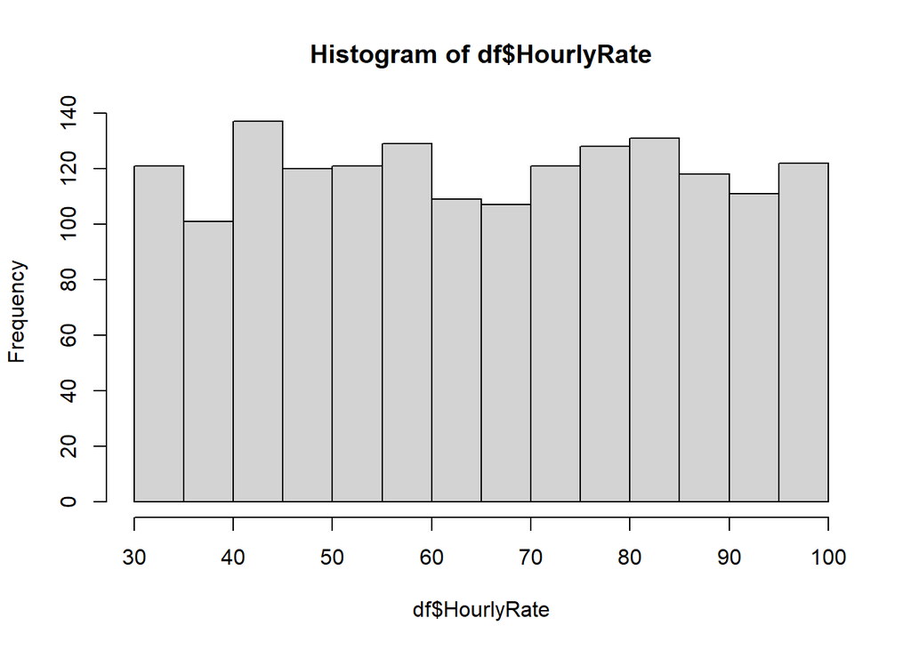

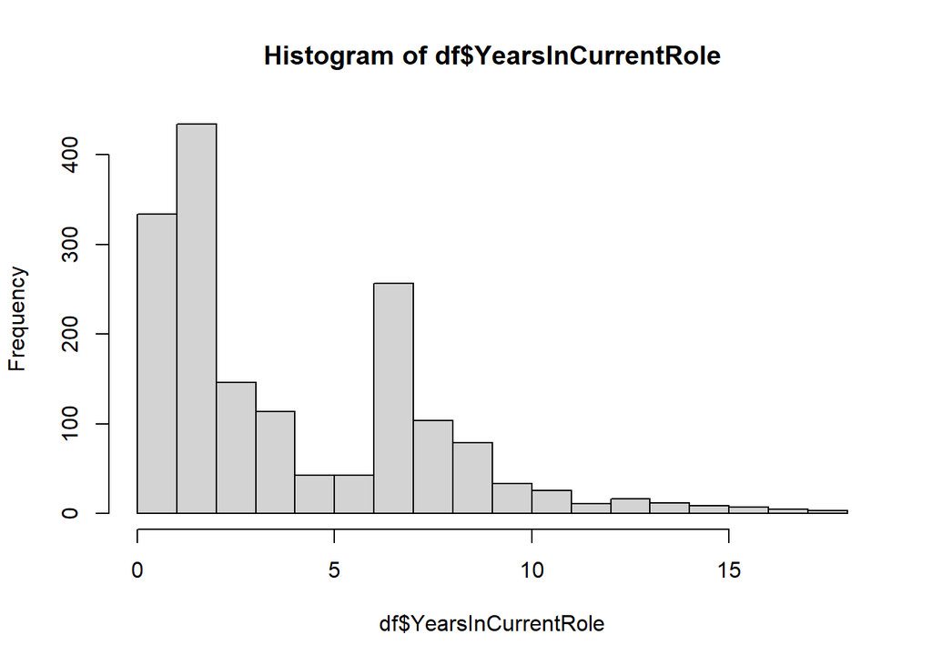

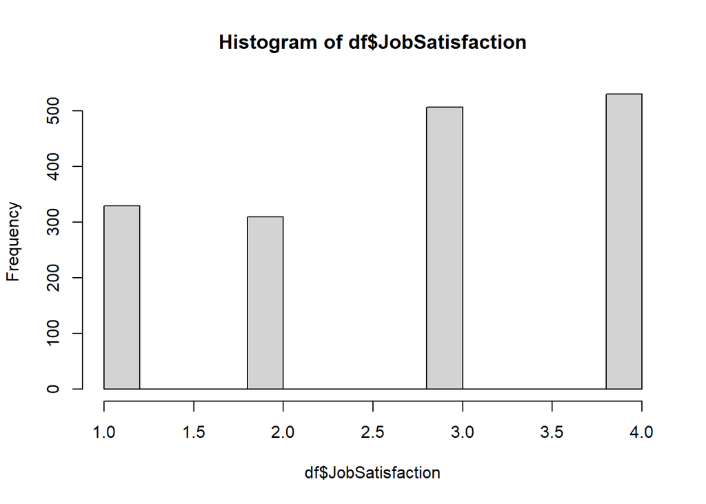

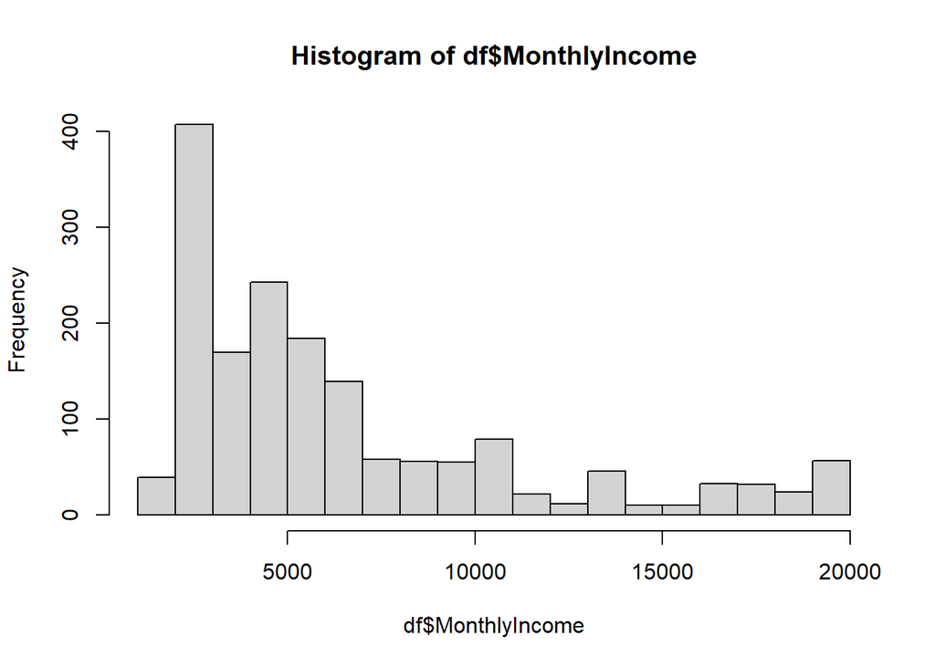

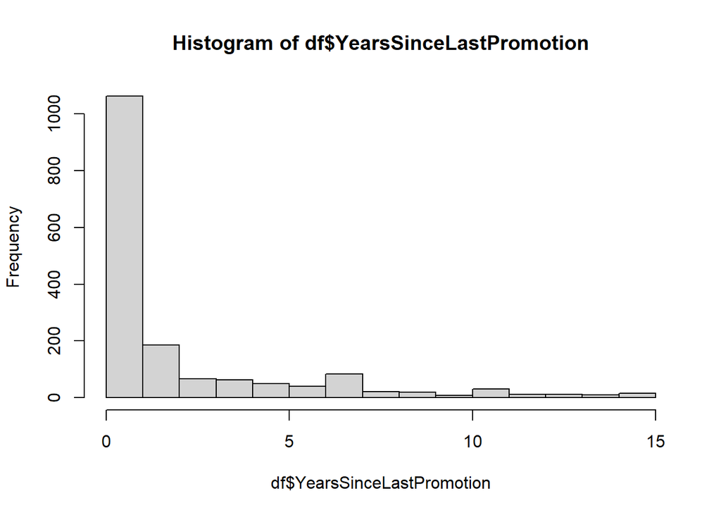

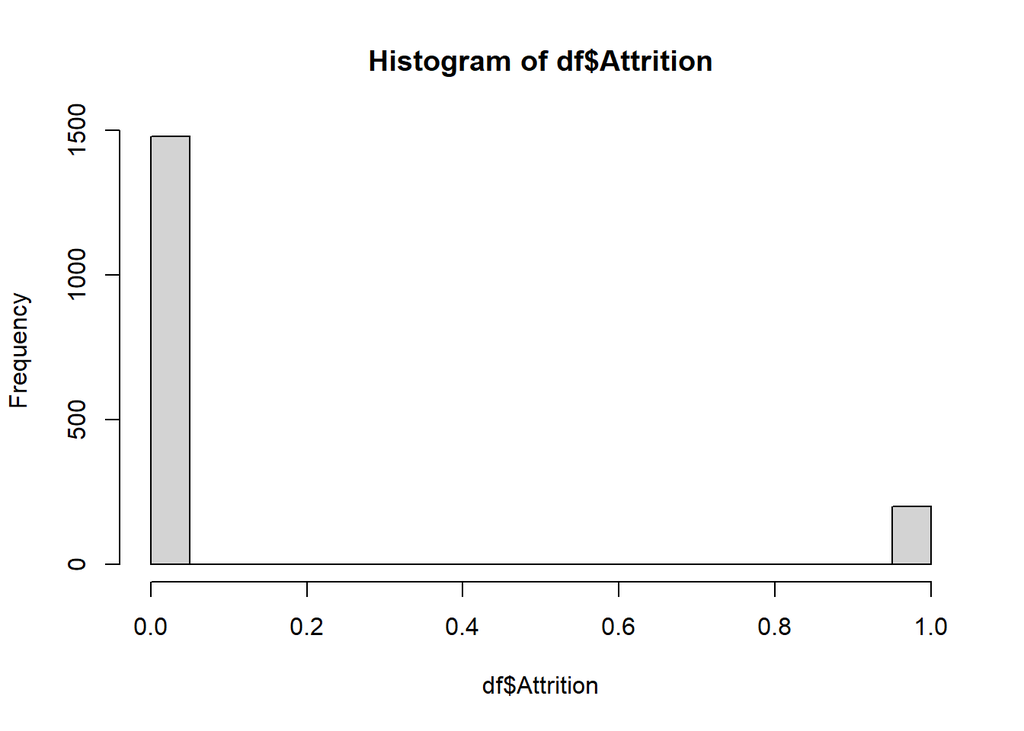

#### **Question-8: Pickup 5 most important numerical columns (if you have), including target variable from your dataset and get a boxplot for each. Comment on skewness of the distribution.**

#### **The charts below show the boxplots**

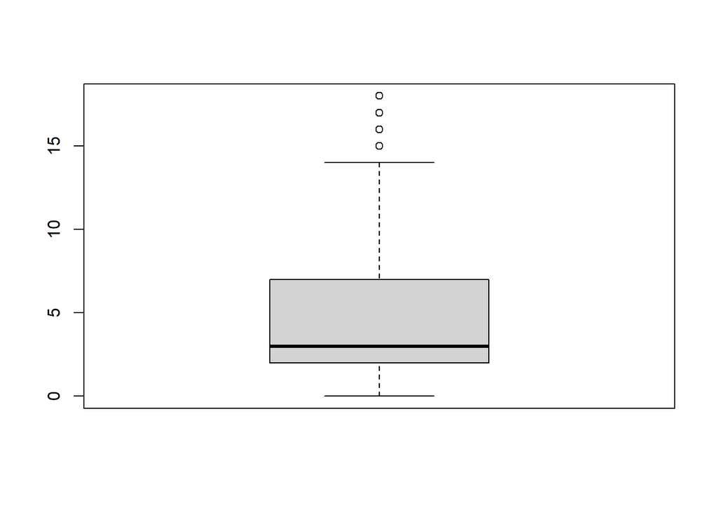

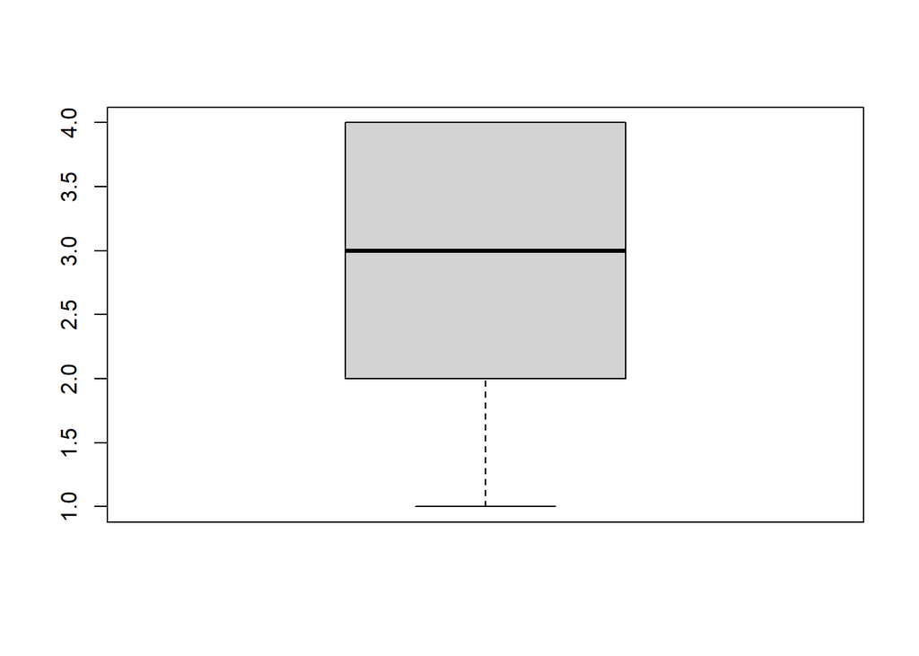

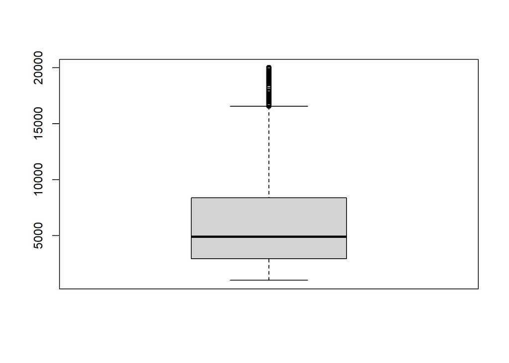

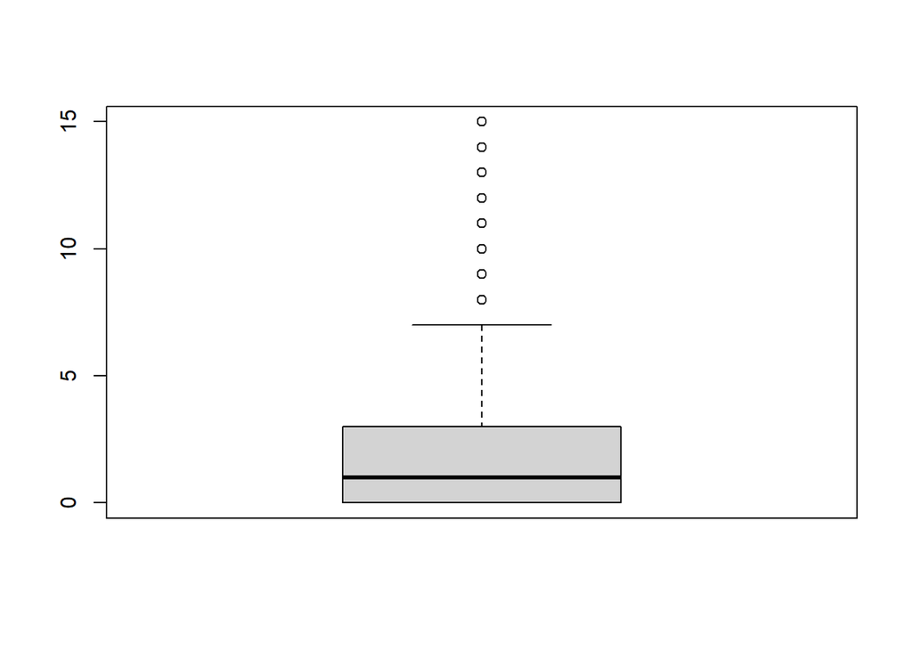

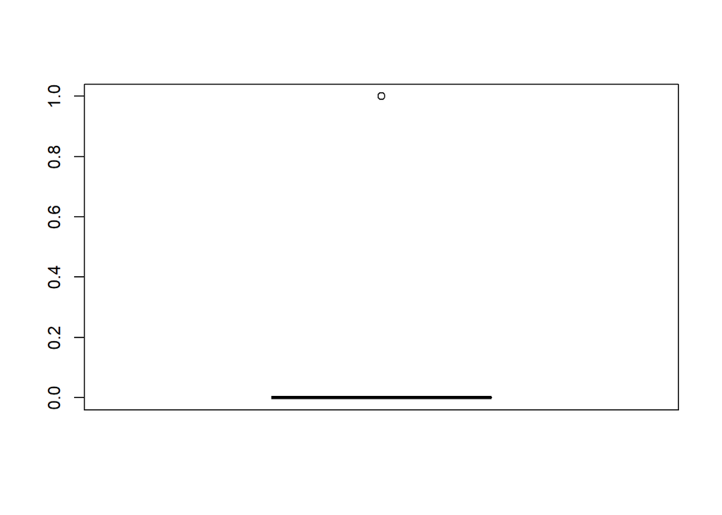

#### **First chart which is YearsInCurrentRole is right skewed. JobSatisfaction, MonthlyIncome, YearsSinceLastPromotion, variables are left, right and right skewed respectively. Attrition is right skewed.**

#### **Question-9: Pickup 5 most important numerical columns, including target variable from your dataset and get a scatter plot matrix. Which ones are correlated with the target variable?**

#### **The scatter plot matrix is below**

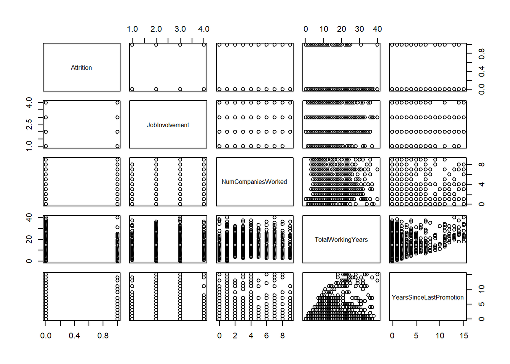

#### **My target variable is Attrition. I look at the scatter plot matrix from the perspective of Attrition being in the y-axis. Looking at the plot, there is hardly any highly positive correlation between target variable and predictor variables. It looks like Attrition and JobInvolvement and TotalWorkingYears are slightly negatively correlated.**

#### **Question-10: By looking at the correlations observed from the scatter plot matrix, can you propose some predictors for your target variable?**

#### **I propose JobInvolvement and TotalWorkingYears as predictors for my target variable Attrition. I also provide below correlations matrix between these variables**

```
##                           Attrition JobInvolvement NumCompaniesWorked
## Attrition                1.00000000   -0.166036254         0.01727934
## JobInvolvement          -0.16603625    1.000000000         0.01630260
## NumCompaniesWorked       0.01727934    0.016302604         1.00000000
## TotalWorkingYears       -0.23418187   -0.001575581         0.25051379
## YearsSinceLastPromotion -0.08620662   -0.022153303        -0.02503340
##                         TotalWorkingYears YearsSinceLastPromotion
## Attrition                    -0.234181873             -0.08620662
## JobInvolvement               -0.001575581             -0.02215330
## NumCompaniesWorked            0.250513793             -0.02503340
## TotalWorkingYears             1.000000000              0.39494103
## YearsSinceLastPromotion       0.394941027              1.00000000
```

#### **Question-11: Pickup 4 pairs of numerical and categorical variables (if you have), from your dataset and get a box plot for each pair. Categorical variable in the x-axis, and numerical variable in the y-axis. Which pairs are correlated?**

#### **The categorical columns I selected are as follows. The boxplots are below**

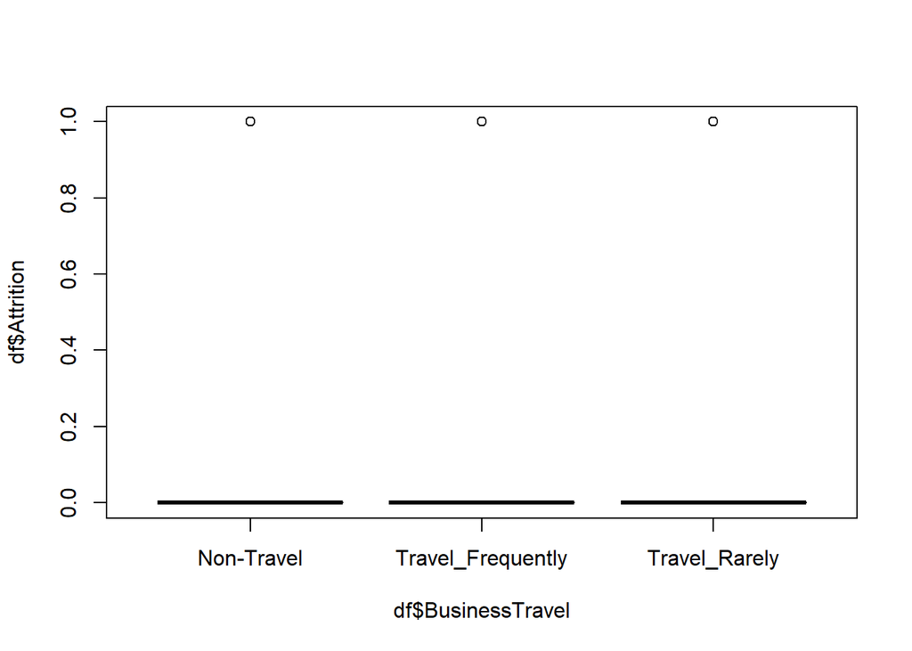

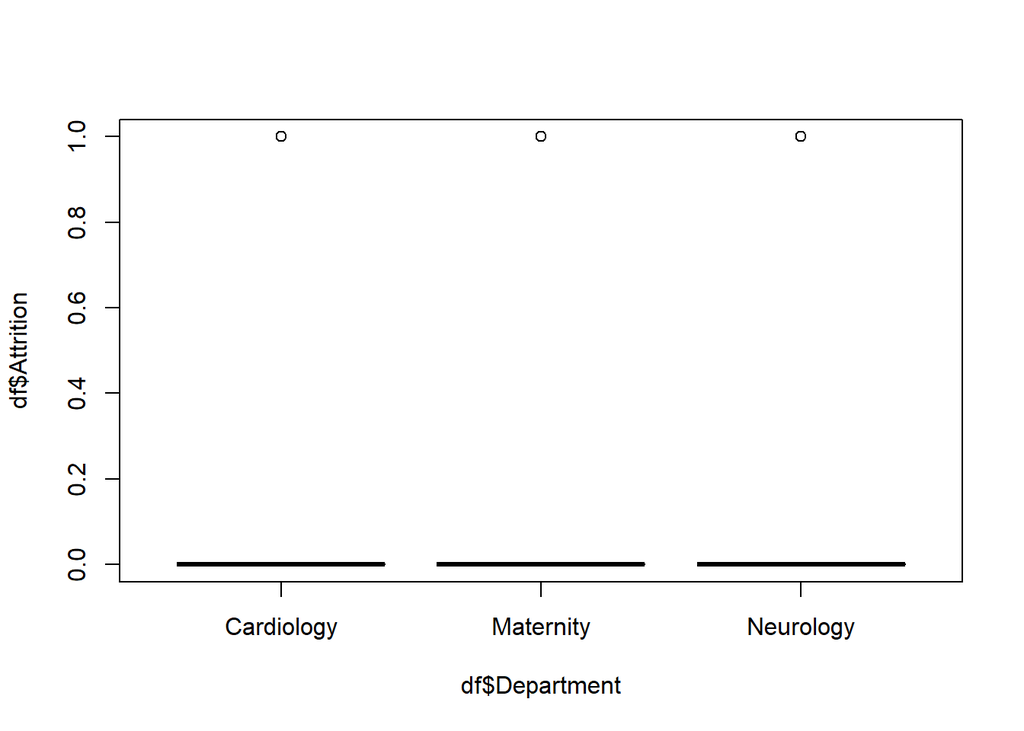

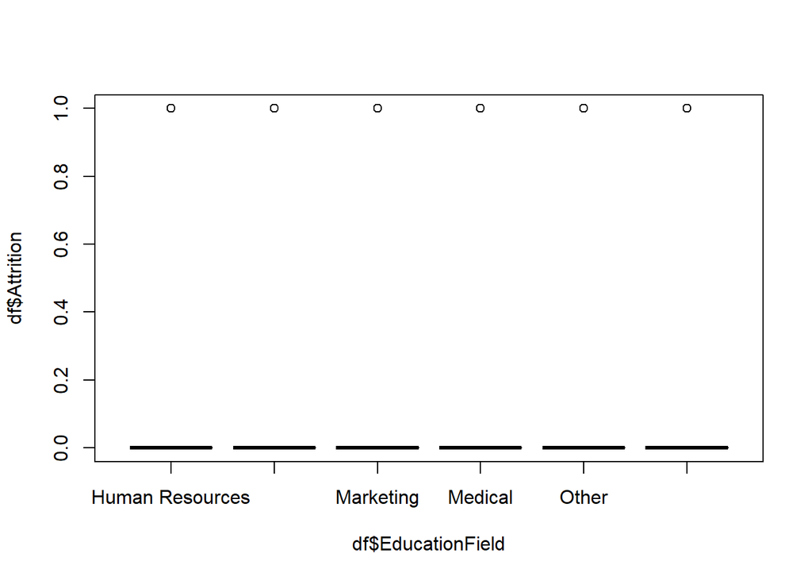

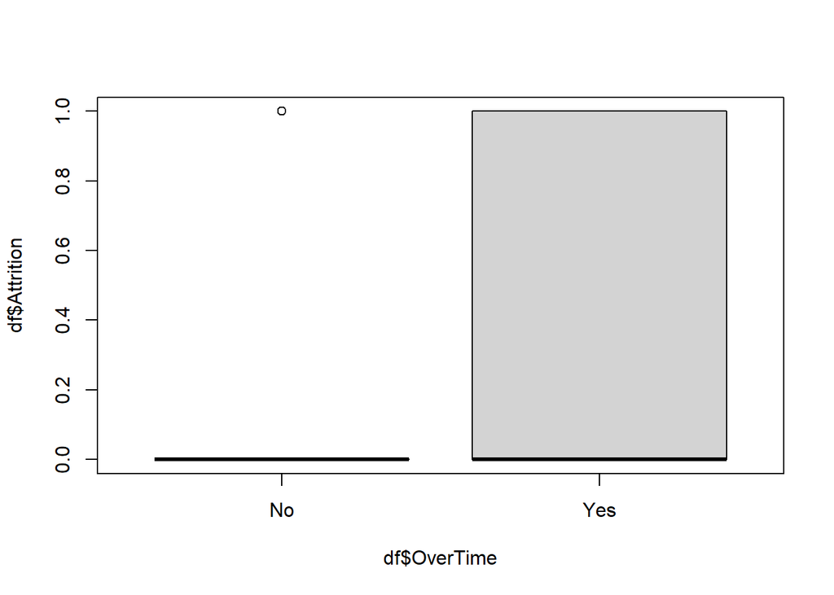

#### **Question-12: By looking at the boxplots, can you propose some categorical predictors for your target variable?**

#### **It is not clear which categorical variables are ordinal in the dataset. Even if we know this, it is not clear the order of the categories. The only exception is the OverTime variable where the cars are getting bigger from left to write in the x-axis. It seems Attrition goes up as the OverTime are getting higher class. Therefore, I can propose OverTime variable as categorical predictor for Attrition.**

```
## [1] 1187
```

```
## [1] 489
```

```r
independentvariables=colnames(df[,4:35])
independentvariables
```

```
##  [1] "BusinessTravel"           "DailyRate"
##  [3] "Department"               "DistanceFromHome"
##  [5] "Education"                "EducationField"
##  [7] "EmployeeCount"            "EnvironmentSatisfaction"
##  [9] "Gender"                   "HourlyRate"
## [11] "JobInvolvement"           "JobLevel"
## [13] "JobRole"                  "JobSatisfaction"
## [15] "MaritalStatus"            "MonthlyIncome"
## [17] "MonthlyRate"              "NumCompaniesWorked"
## [19] "Over18"                   "OverTime"
## [21] "PercentSalaryHike"        "PerformanceRating"
## [23] "RelationshipSatisfaction" "StandardHours"
## [25] "Shift"                    "TotalWorkingYears"
## [27] "TrainingTimesLastYear"    "WorkLifeBalance"
## [29] "YearsAtCompany"           "YearsInCurrentRole"
## [31] "YearsSinceLastPromotion"  "YearsWithCurrManager"
```

```r
Model=paste(independentvariables,collapse="+")
Model
```

```
## [1] "BusinessTravel+DailyRate+Department+DistanceFromHome+Educati…"
```

```r
Model_1=paste("Attrition~",Model)
Model_1
```

```
## [1] "Attrition~ BusinessTravel+DailyRate+Department+DistanceFromHome+Educati…"
```

```r
class(Model_1)
```

```
## [1] "character"
```

```r
formula=as.formula(Model_1)
formula
```

```
## Attrition ~ BusinessTravel + DailyRate + Department + DistanceFromHome +
##     Education + EducationField + EmployeeCount + EnvironmentSatisfaction +
##     Gender + HourlyRate + JobInvolvement + JobLevel + JobRole +
##     JobSatisfaction + MaritalStatus + MonthlyIncome + MonthlyRate +
##     NumCompaniesWorked + Over18 + OverTime + PercentSalaryHike +
##     PerformanceRating + RelationshipSatisfaction + StandardHours +
##     Shift + TotalWorkingYears + TrainingTimesLastYear + WorkLifeBalance +
##     YearsAtCompany + YearsInCurrentRole + YearsSinceLastPromotion +
##     YearsWithCurrManager
```

```r
Trainingmodel1=glm(formula=formula,data=TrainingData,family="binomial")
Trainingmodel1=step(object = Trainingmodel1,direction = "both")
```

```
## Start:  AIC=400.78
## Attrition ~ BusinessTravel + DailyRate + Department + DistanceFromHome +
##     Education + EducationField + EmployeeCount + EnvironmentSatisfaction +
##     Gender + HourlyRate + JobInvolvement + JobLevel + JobRole +
##     JobSatisfaction + MaritalStatus + MonthlyIncome + MonthlyRate +
##     NumCompaniesWorked + Over18 + OverTime + PercentSalaryHike +
##     PerformanceRating + RelationshipSatisfaction + StandardHours +
##     Shift + TotalWorkingYears + TrainingTimesLastYear + WorkLifeBalance +
##     YearsAtCompany + YearsInCurrentRole + YearsSinceLastPromotion +
##     YearsWithCurrManager
```

[output not shown]

```
##
## Step:  AIC=400.78
## Attrition ~ BusinessTravel + DailyRate + Department + DistanceFromHome +
##     Education + EducationField + EmployeeCount + EnvironmentSatisfaction +
##     Gender + HourlyRate + JobInvolvement + JobLevel + JobRole +
##     JobSatisfaction + MaritalStatus + MonthlyIncome + MonthlyRate +
##     NumCompaniesWorked + Over18 + OverTime + PercentSalaryHike +
##     PerformanceRating + RelationshipSatisfaction + Shift + TotalWorkingYears +
##     TrainingTimesLastYear + WorkLifeBalance + YearsAtCompany +
##     YearsInCurrentRole + YearsSinceLastPromotion + YearsWithCurrManager
```

[output not shown]

```
##
## Step:  AIC=400.78
## Attrition ~ BusinessTravel + DailyRate + Department + DistanceFromHome +
##     Education + EducationField + EmployeeCount + EnvironmentSatisfaction +
##     Gender + HourlyRate + JobInvolvement + JobLevel + JobRole +
##     JobSatisfaction + MaritalStatus + MonthlyIncome + MonthlyRate +
##     NumCompaniesWorked + OverTime + PercentSalaryHike + PerformanceRating +
##     RelationshipSatisfaction + Shift + TotalWorkingYears + TrainingTimesLastYear +
##     WorkLifeBalance + YearsAtCompany + YearsInCurrentRole + YearsSinceLastPromotion +
##     YearsWithCurrManager
```

[output not shown]

```
##
## Step:  AIC=400.78
## Attrition ~ BusinessTravel + DailyRate + Department + DistanceFromHome +
##     Education + EducationField + EnvironmentSatisfaction + Gender +
##     HourlyRate + JobInvolvement + JobLevel + JobRole + JobSatisfaction +
##     MaritalStatus + MonthlyIncome + MonthlyRate + NumCompaniesWorked +
##     OverTime + PercentSalaryHike + PerformanceRating + RelationshipSatisfaction +
##     Shift + TotalWorkingYears + TrainingTimesLastYear + WorkLifeBalance +
##     YearsAtCompany + YearsInCurrentRole + YearsSinceLastPromotion +
##     YearsWithCurrManager
```

[output not shown]

```
##                            Df Deviance    AIC
## - PerformanceRating         1   320.78 398.78
## - Gender                    1   320.84 398.84
## - PercentSalaryHike         1   320.84 398.84
## - JobLevel                  1   320.87 398.87
## - MonthlyRate               1   320.99 398.99
## - DailyRate                 1   321.11 399.11
## - Department                2   323.28 399.28
## - HourlyRate                1   321.67 399.67
## - Education                 1   322.20 400.20
## - YearsAtCompany            1   322.55 400.55
## - YearsWithCurrManager      1   322.58 400.58
## <none>                          320.78 400.78
## - Shift                     1   323.71 401.71
## - TrainingTimesLastYear     1   324.11 402.11
## - JobRole                   4   330.30 402.30
## - MonthlyIncome             1   324.34 402.34
## - EducationField            5   338.92 408.92
## - YearsSinceLastPromotion   1   330.98 408.98
## - RelationshipSatisfaction  1   332.67 410.67
## - YearsInCurrentRole        1   333.22 411.22
## - MaritalStatus             2   338.66 414.66
## - BusinessTravel            2   339.65 415.65
## - NumCompaniesWorked        1   339.23 417.23
## - WorkLifeBalance           1   343.87 421.87
## - JobSatisfaction           1   345.43 423.43
## - JobInvolvement            1   351.27 429.27
## - TotalWorkingYears         1   352.13 430.13
## - DistanceFromHome          1   352.18 430.18
## - EnvironmentSatisfaction   1   358.59 436.59
## - OverTime                  1   518.89 596.89
```

```
##
## Step:  AIC=398.78
## Attrition ~ BusinessTravel + DailyRate + Department + DistanceFromHome +
##     Education + EducationField + EnvironmentSatisfaction + Gender +
##     HourlyRate + JobInvolvement + JobLevel + JobRole + JobSatisfaction +
##     MaritalStatus + MonthlyIncome + MonthlyRate + NumCompaniesWorked +
##     OverTime + PercentSalaryHike + RelationshipSatisfaction +
##     Shift + TotalWorkingYears + TrainingTimesLastYear + WorkLifeBalance +
##     YearsAtCompany + YearsInCurrentRole + YearsSinceLastPromotion +
##     YearsWithCurrManager
```

[output not shown]

```
##                            Df Deviance    AIC
## - Gender                    1   320.84 396.84
## - JobLevel                  1   320.87 396.87
## - PercentSalaryHike         1   320.90 396.90
## - MonthlyRate               1   320.99 396.99
## - DailyRate                 1   321.11 397.11
## - Department                2   323.28 397.28
## - HourlyRate                1   321.67 397.67
## - Education                 1   322.22 398.22
## - YearsAtCompany            1   322.57 398.57
## - YearsWithCurrManager      1   322.60 398.60
## <none>                          320.78 398.78
## - Shift                     1   323.72 399.72
## - TrainingTimesLastYear     1   324.14 400.14
## - JobRole                   4   330.31 400.31
## - MonthlyIncome             1   324.38 400.38
## + PerformanceRating         1   320.78 400.78
## - YearsSinceLastPromotion   1   331.01 407.01
## - EducationField            5   339.13 407.13
## - RelationshipSatisfaction  1   332.68 408.68
## - YearsInCurrentRole        1   333.23 409.23
## - MaritalStatus             2   338.69 412.69
## - BusinessTravel            2   339.75 413.75
## - NumCompaniesWorked        1   339.42 415.42
## - WorkLifeBalance           1   343.92 419.92
## - JobSatisfaction           1   345.47 421.47
## - JobInvolvement            1   351.27 427.27
## - TotalWorkingYears         1   352.13 428.13
## - DistanceFromHome          1   352.45 428.45
## - EnvironmentSatisfaction   1   358.63 434.63
## - OverTime                  1   519.74 595.74
```

```
##
## Step:  AIC=396.84
## Attrition ~ BusinessTravel + DailyRate + Department + DistanceFromHome +
##     Education + EducationField + EnvironmentSatisfaction + HourlyRate +
##     JobInvolvement + JobLevel + JobRole + JobSatisfaction + MaritalStatus +
##     MonthlyIncome + MonthlyRate + NumCompaniesWorked + OverTime +
##     PercentSalaryHike + RelationshipSatisfaction + Shift + TotalWorkingYears +
##     TrainingTimesLastYear + WorkLifeBalance + YearsAtCompany +
##     YearsInCurrentRole + YearsSinceLastPromotion + YearsWithCurrManager
```

[output not shown]

```
##                            Df Deviance    AIC
## - JobLevel                  1   320.93 394.93
## - PercentSalaryHike         1   320.96 394.96
## - MonthlyRate               1   321.08 395.08
## - DailyRate                 1   321.17 395.17
## - Department                2   323.40 395.40
## - HourlyRate                1   321.78 395.78
## - Education                 1   322.26 396.26
## - YearsWithCurrManager      1   322.63 396.63
## - YearsAtCompany            1   322.64 396.64
## <none>                          320.84 396.84
## - Shift                     1   323.82 397.82
## - TrainingTimesLastYear     1   324.14 398.14
## - JobRole                   4   330.35 398.35
## - MonthlyIncome             1   324.46 398.46
## + Gender                    1   320.78 398.78
## + PerformanceRating         1   320.84 398.84
## - EducationField            5   339.17 405.17
## - YearsSinceLastPromotion   1   331.19 405.19
## - RelationshipSatisfaction  1   332.90 406.90
## - YearsInCurrentRole        1   333.40 407.40
## - MaritalStatus             2   338.91 410.91
## - BusinessTravel            2   340.25 412.25
## - NumCompaniesWorked        1   339.77 413.77
## - WorkLifeBalance           1   343.95 417.95
## - JobSatisfaction           1   345.64 419.64
## - JobInvolvement            1   351.51 425.51
## - TotalWorkingYears         1   352.64 426.64
## - DistanceFromHome          1   352.75 426.75
## - EnvironmentSatisfaction   1   358.74 432.74
## - OverTime                  1   521.54 595.54
```

```
##
## Step:  AIC=394.93
## Attrition ~ BusinessTravel + DailyRate + Department + DistanceFromHome +
##     Education + EducationField + EnvironmentSatisfaction + HourlyRate +
##     JobInvolvement + JobRole + JobSatisfaction + MaritalStatus +
##     MonthlyIncome + MonthlyRate + NumCompaniesWorked + OverTime +
##     PercentSalaryHike + RelationshipSatisfaction + Shift + TotalWorkingYears +
##     TrainingTimesLastYear + WorkLifeBalance + YearsAtCompany +
##     YearsInCurrentRole + YearsSinceLastPromotion + YearsWithCurrManager
```

[output not shown]

```
##                            Df Deviance    AIC
## - PercentSalaryHike         1   321.05 393.05
## - MonthlyRate               1   321.16 393.16
## - DailyRate                 1   321.26 393.26
## - Department                2   323.40 393.40
## - HourlyRate                1   321.83 393.83
## - Education                 1   322.43 394.43
## - YearsAtCompany            1   322.65 394.65
## - YearsWithCurrManager      1   322.67 394.67
## <none>                          320.93 394.93
## - Shift                     1   323.96 395.96
## - TrainingTimesLastYear     1   324.19 396.19
## - JobRole                   4   330.39 396.39
## + JobLevel                  1   320.84 396.84
## + Gender                    1   320.87 396.87
## + PerformanceRating         1   320.93 396.93
## - MonthlyIncome             1   330.77 402.77
## - EducationField            5   339.22 403.22
## - YearsSinceLastPromotion   1   331.40 403.40
## - RelationshipSatisfaction  1   333.02 405.02
## - YearsInCurrentRole        1   333.40 405.40
## - MaritalStatus             2   338.94 408.94
## - BusinessTravel            2   340.38 410.38
## - NumCompaniesWorked        1   339.95 411.95
## - WorkLifeBalance           1   344.38 416.38
## - JobSatisfaction           1   345.70 417.70
## - JobInvolvement            1   351.52 423.52
## - DistanceFromHome          1   352.78 424.78
## - TotalWorkingYears         1   355.73 427.73
## - EnvironmentSatisfaction   1   358.76 430.76
## - OverTime                  1   521.67 593.67
```

```
##
## Step:  AIC=393.05
## Attrition ~ BusinessTravel + DailyRate + Department + DistanceFromHome +
##     Education + EducationField + EnvironmentSatisfaction + HourlyRate +
##     JobInvolvement + JobRole + JobSatisfaction + MaritalStatus +
##     MonthlyIncome + MonthlyRate + NumCompaniesWorked + OverTime +
##     RelationshipSatisfaction + Shift + TotalWorkingYears + TrainingTimesLastYear +
##     WorkLifeBalance + YearsAtCompany + YearsInCurrentRole + YearsSinceLastPromotion +
##     YearsWithCurrManager
```

[output not shown]

```
##                            Df Deviance    AIC
## - MonthlyRate               1   321.31 391.31
## - DailyRate                 1   321.40 391.40
## - Department                2   323.41 391.41
## - HourlyRate                1   321.96 391.96
## - Education                 1   322.54 392.54
## - YearsWithCurrManager      1   322.75 392.75
## - YearsAtCompany            1   322.77 392.77
## <none>                          321.05 393.05
## - Shift                     1   324.07 394.07
## - TrainingTimesLastYear     1   324.22 394.22
## - JobRole                   4   330.47 394.47
## + PercentSalaryHike         1   320.93 394.93
## + JobLevel                  1   320.96 394.96
## + Gender                    1   320.99 394.99
## + PerformanceRating         1   321.00 395.00
## - MonthlyIncome             1   330.79 400.79
## - YearsSinceLastPromotion   1   331.41 401.41
## - EducationField            5   339.44 401.44
## - RelationshipSatisfaction  1   333.12 403.12
## - YearsInCurrentRole        1   333.42 403.42
## - MaritalStatus             2   339.02 407.02
## - BusinessTravel            2   340.86 408.86
## - NumCompaniesWorked        1   340.27 410.27
## - WorkLifeBalance           1   344.38 414.38
## - JobSatisfaction           1   345.71 415.71
## - JobInvolvement            1   351.63 421.63
## - DistanceFromHome          1   352.78 422.78
## - TotalWorkingYears         1   356.43 426.43
## - EnvironmentSatisfaction   1   358.83 428.83
## - OverTime                  1   521.73 591.73
```

```
##
## Step:  AIC=391.31
## Attrition ~ BusinessTravel + DailyRate + Department + DistanceFromHome +
##     Education + EducationField + EnvironmentSatisfaction + HourlyRate +
##     JobInvolvement + JobRole + JobSatisfaction + MaritalStatus +
##     MonthlyIncome + NumCompaniesWorked + OverTime + RelationshipSatisfaction +
##     Shift + TotalWorkingYears + TrainingTimesLastYear + WorkLifeBalance +
##     YearsAtCompany + YearsInCurrentRole + YearsSinceLastPromotion +
##     YearsWithCurrManager
```

[output not shown]

```
##                            Df Deviance    AIC
## - Department                2   323.68 389.68
## - DailyRate                 1   321.72 389.72
## - HourlyRate                1   322.27 390.27
## - Education                 1   322.66 390.66
## - YearsAtCompany            1   322.92 390.92
## - YearsWithCurrManager      1   322.96 390.96
## <none>                          321.31 391.31
## - TrainingTimesLastYear     1   324.48 392.48
## - JobRole                   4   330.49 392.49
## - Shift                     1   324.59 392.59
## + MonthlyRate               1   321.05 393.05
## + PercentSalaryHike         1   321.16 393.16
## + Gender                    1   321.21 393.21
## + PerformanceRating         1   321.23 393.23
## + JobLevel                  1   321.23 393.23
## - MonthlyIncome             1   330.83 398.83
## - EducationField            5   339.49 399.49
## - YearsSinceLastPromotion   1   331.65 399.65
## - RelationshipSatisfaction  1   333.31 401.31
## - YearsInCurrentRole        1   333.48 401.48
## - MaritalStatus             2   339.02 405.02
## - BusinessTravel            2   341.21 407.21
## - NumCompaniesWorked        1   340.43 408.43
## - WorkLifeBalance           1   344.44 412.44
## - JobSatisfaction           1   345.81 413.81
## - JobInvolvement            1   351.73 419.73
## - DistanceFromHome          1   353.95 421.95
## - TotalWorkingYears         1   356.81 424.81
## - EnvironmentSatisfaction   1   358.86 426.86
## - OverTime                  1   521.77 589.77
```

```
##
## Step:  AIC=389.68
## Attrition ~ BusinessTravel + DailyRate + DistanceFromHome + Education +
##     EducationField + EnvironmentSatisfaction + HourlyRate + JobInvolvement +
##     JobRole + JobSatisfaction + MaritalStatus + MonthlyIncome +
##     NumCompaniesWorked + OverTime + RelationshipSatisfaction +
##     Shift + TotalWorkingYears + TrainingTimesLastYear + WorkLifeBalance +
##     YearsAtCompany + YearsInCurrentRole + YearsSinceLastPromotion +
##     YearsWithCurrManager
```

[output not shown]

```
##                            Df Deviance    AIC
## - DailyRate                 1   324.02 388.02
## - HourlyRate                1   324.74 388.74
## - Education                 1   324.88 388.88
## - YearsWithCurrManager      1   325.19 389.19
## - YearsAtCompany            1   325.36 389.36
## <none>                          323.68 389.68
## - TrainingTimesLastYear     1   326.64 390.64
## - Shift                     1   326.72 390.72
## - JobRole                   4   332.97 390.97
## + Department                2   321.31 391.31
## + MonthlyRate               1   323.41 391.41
## + Gender                    1   323.51 391.51
## + PercentSalaryHike         1   323.65 391.65
## + PerformanceRating         1   323.67 391.67
## + JobLevel                  1   323.67 391.67
## - MonthlyIncome             1   331.78 395.78
## - YearsSinceLastPromotion   1   334.32 398.32
## - RelationshipSatisfaction  1   335.33 399.33
## - EducationField            5   344.02 400.02
## - YearsInCurrentRole        1   336.09 400.09
## - BusinessTravel            2   342.52 404.52
## - MaritalStatus             2   342.61 404.61
## - NumCompaniesWorked        1   343.26 407.26
## - WorkLifeBalance           1   345.15 409.15
## - JobSatisfaction           1   348.48 412.48
## - JobInvolvement            1   354.73 418.73
## - DistanceFromHome          1   355.59 419.59
## - TotalWorkingYears         1   360.34 424.34
## - EnvironmentSatisfaction   1   361.95 425.95
## - OverTime                  1   522.49 586.49
```

```
##
## Step:  AIC=388.02
## Attrition ~ BusinessTravel + DistanceFromHome + Education + EducationField +
##     EnvironmentSatisfaction + HourlyRate + JobInvolvement + JobRole +
##     JobSatisfaction + MaritalStatus + MonthlyIncome + NumCompaniesWorked +
##     OverTime + RelationshipSatisfaction + Shift + TotalWorkingYears +
##     TrainingTimesLastYear + WorkLifeBalance + YearsAtCompany +
##     YearsInCurrentRole + YearsSinceLastPromotion + YearsWithCurrManager
```

[output not shown]

```
##                            Df Deviance    AIC
## - HourlyRate                1   325.03 387.03
## - Education                 1   325.30 387.30
## - YearsWithCurrManager      1   325.56 387.56
## - YearsAtCompany            1   325.70 387.70
## <none>                          324.02 388.02
## - Shift                     1   326.97 388.97
## - JobRole                   4   333.00 389.00
## - TrainingTimesLastYear     1   327.10 389.10
## + DailyRate                 1   323.68 389.68
## + MonthlyRate               1   323.70 389.70
## + Department                2   321.72 389.72
## + Gender                    1   323.87 389.87
## + PercentSalaryHike         1   323.98 389.98
## + PerformanceRating         1   323.99 389.99
## + JobLevel                  1   324.01 390.01
## - MonthlyIncome             1   332.07 394.07
## - YearsSinceLastPromotion   1   335.00 397.00
## - RelationshipSatisfaction  1   336.01 398.01
## - EducationField            5   344.42 398.42
## - YearsInCurrentRole        1   336.46 398.46
## - BusinessTravel            2   342.84 402.84
## - MaritalStatus             2   343.82 403.82
## - NumCompaniesWorked        1   343.29 405.29
## - WorkLifeBalance           1   345.74 407.74
## - JobSatisfaction           1   349.56 411.56
## - JobInvolvement            1   355.73 417.73
## - DistanceFromHome          1   356.55 418.55
## - TotalWorkingYears         1   361.23 423.23
## - EnvironmentSatisfaction   1   363.07 425.07
## - OverTime                  1   522.49 584.49
```

```
##
## Step:  AIC=387.03
## Attrition ~ BusinessTravel + DistanceFromHome + Education + EducationField +
##     EnvironmentSatisfaction + JobInvolvement + JobRole + JobSatisfaction +
##     MaritalStatus + MonthlyIncome + NumCompaniesWorked + OverTime +
##     RelationshipSatisfaction + Shift + TotalWorkingYears + TrainingTimesLastYear +
##     WorkLifeBalance + YearsAtCompany + YearsInCurrentRole + YearsSinceLastPromotion +
##     YearsWithCurrManager
```

[output not shown]

```
##                            Df Deviance    AIC
## - Education                 1   326.17 386.17
## - YearsAtCompany            1   326.59 386.59
## - YearsWithCurrManager      1   326.60 386.60
## <none>                          325.03 387.03
## - JobRole                   4   333.62 387.62
## - TrainingTimesLastYear     1   327.88 387.88
## - Shift                     1   327.94 387.94
## + HourlyRate                1   324.02 388.02
## + Department                2   322.61 388.61
## + MonthlyRate               1   324.67 388.67
## + DailyRate                 1   324.74 388.74
## + Gender                    1   324.81 388.81
## + PercentSalaryHike         1   324.97 388.97
## + PerformanceRating         1   324.99 388.99
## + JobLevel                  1   325.01 389.01
## - MonthlyIncome             1   332.84 392.84
## - YearsSinceLastPromotion   1   335.48 395.48
## - RelationshipSatisfaction  1   336.80 396.80
## - YearsInCurrentRole        1   337.13 397.13
## - EducationField            5   346.27 398.27
## - BusinessTravel            2   343.20 401.20
## - MaritalStatus             2   345.08 403.08
## - NumCompaniesWorked        1   344.41 404.41
## - WorkLifeBalance           1   346.84 406.84
## - JobSatisfaction           1   350.78 410.78
## - JobInvolvement            1   356.10 416.10
## - DistanceFromHome          1   357.17 417.17
## - TotalWorkingYears         1   361.86 421.86
## - EnvironmentSatisfaction   1   364.01 424.01
## - OverTime                  1   522.59 582.59
```

```
##
## Step:  AIC=386.17
## Attrition ~ BusinessTravel + DistanceFromHome + EducationField +
##     EnvironmentSatisfaction + JobInvolvement + JobRole + JobSatisfaction +
##     MaritalStatus + MonthlyIncome + NumCompaniesWorked + OverTime +
##     RelationshipSatisfaction + Shift + TotalWorkingYears + TrainingTimesLastYear +
##     WorkLifeBalance + YearsAtCompany + YearsInCurrentRole + YearsSinceLastPromotion +
##     YearsWithCurrManager
```

[output not shown]

```
##                            Df Deviance    AIC
## - YearsWithCurrManager      1   327.68 385.68
## - YearsAtCompany            1   327.75 385.75
## <none>                          326.17 386.17
## - JobRole                   4   334.48 386.48
## - TrainingTimesLastYear     1   328.89 386.89
## - Shift                     1   329.00 387.00
## + Education                 1   325.03 387.03
## + HourlyRate                1   325.30 387.30
## + DailyRate                 1   325.82 387.82
## + Department                2   323.94 387.94
## + MonthlyRate               1   325.97 387.97
## + Gender                    1   326.00 388.00
## + PercentSalaryHike         1   326.12 388.12
## + PerformanceRating         1   326.15 388.15
## + JobLevel                  1   326.17 388.17
## - MonthlyIncome             1   334.08 392.08
## - YearsSinceLastPromotion   1   336.51 394.51
## - YearsInCurrentRole        1   337.82 395.82
## - RelationshipSatisfaction  1   337.93 395.93
## - EducationField            5   347.74 397.74
## - BusinessTravel            2   344.17 400.17
## - MaritalStatus             2   345.83 401.83
## - NumCompaniesWorked        1   346.21 404.21
## - WorkLifeBalance           1   348.10 406.10
## - JobSatisfaction           1   351.85 409.85
## - JobInvolvement            1   356.87 414.87
## - DistanceFromHome          1   358.24 416.24
## - TotalWorkingYears         1   362.40 420.40
## - EnvironmentSatisfaction   1   364.71 422.71
## - OverTime                  1   523.14 581.14
```

```
##
## Step:  AIC=385.68
## Attrition ~ BusinessTravel + DistanceFromHome + EducationField +
##     EnvironmentSatisfaction + JobInvolvement + JobRole + JobSatisfaction +
##     MaritalStatus + MonthlyIncome + NumCompaniesWorked + OverTime +
##     RelationshipSatisfaction + Shift + TotalWorkingYears + TrainingTimesLastYear +
##     WorkLifeBalance + YearsAtCompany + YearsInCurrentRole + YearsSinceLastPromotion
```

[output not shown]

```
##                            Df Deviance    AIC
## - YearsAtCompany            1   328.07 384.07
## <none>                          327.68 385.68
## - JobRole                   4   336.08 386.08
## + YearsWithCurrManager      1   326.17 386.17
## - TrainingTimesLastYear     1   330.26 386.26
## + Education                 1   326.60 386.60
## - Shift                     1   330.77 386.77
## + HourlyRate                1   326.78 386.78
## + DailyRate                 1   327.31 387.31
## + MonthlyRate               1   327.52 387.52
## + Gender                    1   327.59 387.59
## + Department                2   325.61 387.61
## + PercentSalaryHike         1   327.65 387.65
## + JobLevel                  1   327.66 387.66
## + PerformanceRating         1   327.68 387.68
## - MonthlyIncome             1   335.56 391.56
## - YearsSinceLastPromotion   1   336.96 392.96
## - YearsInCurrentRole        1   338.66 394.66
## - RelationshipSatisfaction  1   339.20 395.20
## - EducationField            5   349.56 397.56
## - BusinessTravel            2   345.81 399.81
## - MaritalStatus             2   346.44 400.44
## - NumCompaniesWorked        1   346.85 402.85
## - WorkLifeBalance           1   349.97 405.97
## - JobSatisfaction           1   352.48 408.48
## - JobInvolvement            1   358.86 414.86
## - DistanceFromHome          1   360.09 416.09
## - TotalWorkingYears         1   363.26 419.26
## - EnvironmentSatisfaction   1   365.49 421.49
## - OverTime                  1   524.65 580.65
```

```
##
## Step:  AIC=384.07
## Attrition ~ BusinessTravel + DistanceFromHome + EducationField +
##     EnvironmentSatisfaction + JobInvolvement + JobRole + JobSatisfaction +
##     MaritalStatus + MonthlyIncome + NumCompaniesWorked + OverTime +
##     RelationshipSatisfaction + Shift + TotalWorkingYears + TrainingTimesLastYear +
##     WorkLifeBalance + YearsInCurrentRole + YearsSinceLastPromotion
```

[output not shown]

```
##                            Df Deviance    AIC
## <none>                          328.07 384.07
## - JobRole                   4   336.25 384.25
## - TrainingTimesLastYear     1   330.54 384.54
## + Education                 1   326.96 384.96
## - Shift                     1   331.16 385.16
## + HourlyRate                1   327.26 385.26
## + YearsAtCompany            1   327.68 385.68
## + DailyRate                 1   327.71 385.71
## + YearsWithCurrManager      1   327.75 385.75
## + Department                2   325.92 385.92
## + Gender                    1   327.95 385.95
## + MonthlyRate               1   327.95 385.95
## + JobLevel                  1   328.03 386.03
## + PercentSalaryHike         1   328.04 386.04
## + PerformanceRating         1   328.07 386.07
## - MonthlyIncome             1   335.59 389.59
## - RelationshipSatisfaction  1   339.39 393.39
## - YearsSinceLastPromotion   1   339.61 393.61
## - EducationField            5   349.64 395.64
## - BusinessTravel            2   345.91 397.91
## - MaritalStatus             2   347.01 399.01
## - YearsInCurrentRole        1   345.29 399.29
## - NumCompaniesWorked        1   347.49 401.49
## - WorkLifeBalance           1   350.44 404.44
## - JobSatisfaction           1   352.51 406.51
## - JobInvolvement            1   358.90 412.90
## - DistanceFromHome          1   360.34 414.34
## - TotalWorkingYears         1   364.57 418.57
## - EnvironmentSatisfaction   1   365.71 419.71
## - OverTime                  1   525.15 579.15
```

```r
summary(Trainingmodel1)
```

```
##
## Call:
## glm(formula = Attrition ~ BusinessTravel + DistanceFromHome +
##     EducationField + EnvironmentSatisfaction + JobInvolvement +
##     JobRole + JobSatisfaction + MaritalStatus + MonthlyIncome +
##     NumCompaniesWorked + OverTime + RelationshipSatisfaction +
##     Shift + TotalWorkingYears + TrainingTimesLastYear + WorkLifeBalance +
##     YearsInCurrentRole + YearsSinceLastPromotion, family = "binomial",
##     data = TrainingData)
##
## Deviance Residuals:
##      Min        1Q    Median        3Q       Max
## -1.99910  -0.19315  -0.05316  -0.00441   3.09005
##
## Coefficients:
##                                   Estimate Std. Error z value Pr(>|z|)
## (Intercept)                      2.287e-01  2.589e+03   0.000 0.999930
## BusinessTravelTravel_Frequently  2.650e+00  7.509e-01   3.529 0.000417 ***
## BusinessTravelTravel_Rarely      1.561e+00  6.901e-01   2.262 0.023691 *
## DistanceFromHome                 1.023e-01  1.888e-02   5.419 5.98e-08 ***
## EducationFieldLife Sciences     -1.527e+00  1.116e+00  -1.368 0.171382
## EducationFieldMarketing         -9.258e-01  1.178e+00  -0.786 0.432089
## EducationFieldMedical           -2.510e+00  1.135e+00  -2.211 0.027020 *
## EducationFieldOther             -1.920e+00  1.317e+00  -1.458 0.144863
## EducationFieldTechnical Degree  -4.520e-01  1.177e+00  -0.384 0.701048
## EnvironmentSatisfaction         -8.298e-01  1.466e-01  -5.662 1.50e-08 ***
## JobInvolvement                  -1.159e+00  2.217e-01  -5.226 1.73e-07 ***
## JobRoleAdministrative           -3.938e+00  2.745e+03  -0.001 0.998855
## JobRoleNurse                     8.012e+00  2.589e+03   0.003 0.997531
## JobRoleOther                     7.435e+00  2.589e+03   0.003 0.997709
## JobRoleTherapist                 6.115e+00  2.589e+03   0.002 0.998116
## JobSatisfaction                 -6.412e-01  1.356e-01  -4.730 2.25e-06 ***
## MaritalStatusMarried             4.340e-01  4.534e-01   0.957 0.338466
## MaritalStatusSingle              2.091e+00  5.804e-01   3.603 0.000315 ***
## MonthlyIncome                   -2.528e-04  9.633e-05  -2.624 0.008689 **
## NumCompaniesWorked               2.863e-01  6.607e-02   4.334 1.46e-05 ***
## OverTimeYes                      4.157e+00  3.897e-01  10.669  < 2e-16 ***
## RelationshipSatisfaction        -4.579e-01  1.396e-01  -3.280 0.001037 **
## Shift                           -4.328e-01  2.493e-01  -1.736 0.082507 .
## TotalWorkingYears               -2.535e-01  4.694e-02  -5.399 6.70e-08 ***
## TrainingTimesLastYear           -1.873e-01  1.203e-01  -1.557 0.119450
## WorkLifeBalance                 -9.543e-01  2.091e-01  -4.563 5.03e-06 ***
## YearsInCurrentRole              -3.134e-01  7.909e-02  -3.962 7.44e-05 ***
## YearsSinceLastPromotion          2.730e-01  7.879e-02   3.466 0.000529 ***
## ---
## Signif. codes:  0 '***' 0.001 '**' 0.01 '*' 0.05 '.' 0.1 ' ' 1
##
## (Dispersion parameter for binomial family taken to be 1)
##
##     Null deviance: 849.16  on 1186  degrees of freedom
## Residual deviance: 328.07  on 1159  degrees of freedom
## AIC: 384.07
##
## Number of Fisher Scoring iterations: 18
```

```
## Start:  AIC=728.5
## Attrition ~ BusinessTravel + Education + EducationField + EnvironmentSatisfaction +
##     JobInvolvement + JobSatisfaction + MonthlyIncome + NumCompaniesWorked +
##     OverTime + RelationshipSatisfaction + TotalWorkingYears +
##     WorkLifeBalance + YearsInCurrentRole + YearsSinceLastPromotion
##
##                            Df Deviance    AIC
## - Education                 1   688.75 726.75
## <none>                          688.50 728.50
## - MonthlyIncome             1   691.52 729.52
## - RelationshipSatisfaction  1   691.84 729.84
## - EducationField            5   704.23 734.23
## - BusinessTravel            2   707.91 743.91
## - WorkLifeBalance           1   706.27 744.27
## - NumCompaniesWorked        1   707.27 745.27
## - YearsSinceLastPromotion   1   707.70 745.70
## - YearsInCurrentRole        1   712.12 750.12
## - JobSatisfaction           1   717.37 755.37
## - EnvironmentSatisfaction   1   727.92 765.92
## - TotalWorkingYears         1   738.18 776.18
## - JobInvolvement            1   741.43 779.43
## - OverTime                  1   925.34 963.34
##
## Step:  AIC=726.75
## Attrition ~ BusinessTravel + EducationField + EnvironmentSatisfaction +
##     JobInvolvement + JobSatisfaction + MonthlyIncome + NumCompaniesWorked +
##     OverTime + RelationshipSatisfaction + TotalWorkingYears +
##     WorkLifeBalance + YearsInCurrentRole + YearsSinceLastPromotion
##
##                            Df Deviance    AIC
## <none>                          688.75 726.75
## - MonthlyIncome             1   691.79 727.79
## - RelationshipSatisfaction  1   692.17 728.17
## + Education                 1   688.50 728.50
## - EducationField            5   704.27 732.27
## - BusinessTravel            2   707.98 741.98
## - WorkLifeBalance           1   706.45 742.45
## - NumCompaniesWorked        1   707.27 743.27
## - YearsSinceLastPromotion   1   707.80 743.80
## - YearsInCurrentRole        1   712.37 748.37
## - JobSatisfaction           1   717.51 753.51
## - EnvironmentSatisfaction   1   727.93 763.93
## - TotalWorkingYears         1   738.82 774.82
## - JobInvolvement            1   742.36 778.36
## - OverTime                  1   925.49 961.49
```

```
##
## Call:
## glm(formula = Attrition ~ BusinessTravel + EducationField + EnvironmentSatisfaction +
##     JobInvolvement + JobSatisfaction + MonthlyIncome + NumCompaniesWorked +
##     OverTime + RelationshipSatisfaction + TotalWorkingYears +
##     WorkLifeBalance + YearsInCurrentRole + YearsSinceLastPromotion,
##     family = binomial, data = df)
##
## Deviance Residuals:
##     Min       1Q   Median       3Q      Max
## -2.2008  -0.3442  -0.1482  -0.0447   4.1892
##
## Coefficients:
##                                   Estimate Std. Error z value Pr(>|z|)
## (Intercept)                      6.400e+00  1.041e+00   6.148 7.87e-10 ***
## BusinessTravelTravel_Frequently  1.119e+00  3.928e-01   2.849  0.00439 **
## BusinessTravelTravel_Rarely      8.763e-02  3.566e-01   0.246  0.80587
## EducationFieldLife Sciences     -9.855e-01  6.740e-01  -1.462  0.14369
## EducationFieldMarketing         -3.781e-01  7.073e-01  -0.535  0.59299
## EducationFieldMedical           -1.400e+00  6.819e-01  -2.053  0.04011 *
## EducationFieldOther             -1.402e+00  7.982e-01  -1.756  0.07902 .
## EducationFieldTechnical Degree  -4.445e-01  7.217e-01  -0.616  0.53795
## EnvironmentSatisfaction         -5.708e-01  9.432e-02  -6.052 1.43e-09 ***
## JobInvolvement                  -9.739e-01  1.382e-01  -7.048 1.82e-12 ***
## JobSatisfaction                 -4.897e-01  9.335e-02  -5.246 1.55e-07 ***
## MonthlyIncome                   -8.664e-05  5.068e-05  -1.710  0.08735 .
## NumCompaniesWorked               1.869e-01  4.338e-02   4.309 1.64e-05 ***
## OverTimeYes                      3.081e+00  2.344e-01  13.146  < 2e-16 ***
## RelationshipSatisfaction        -1.701e-01  9.199e-02  -1.850  0.06438 .
## TotalWorkingYears               -1.955e-01  3.093e-02  -6.321 2.60e-10 ***
## WorkLifeBalance                 -5.748e-01  1.373e-01  -4.186 2.84e-05 ***
## YearsInCurrentRole              -2.360e-01  5.038e-02  -4.683 2.83e-06 ***
## YearsSinceLastPromotion          2.269e-01  5.037e-02   4.504 6.68e-06 ***
## ---
## Signif. codes:  0 '***' 0.001 '**' 0.01 '*' 0.05 '.' 0.1 ' ' 1
##
## (Dispersion parameter for binomial family taken to be 1)
##
##     Null deviance: 1221.46  on 1675  degrees of freedom
## Residual deviance:  688.75  on 1657  degrees of freedom
## AIC: 726.75
##
## Number of Fisher Scoring iterations: 7
```

```
## Start:  AIC=734.28
## Attrition ~ BusinessTravel + EnvironmentSatisfaction + JobInvolvement +
##     JobSatisfaction + NumCompaniesWorked + OverTime + TotalWorkingYears +
##     WorkLifeBalance + YearsInCurrentRole + YearsSinceLastPromotion
##
##                           Df Deviance    AIC
## <none>                         710.28 734.28
## - YearsSinceLastPromotion  1   726.93 748.93
## - WorkLifeBalance          1   727.79 749.79
## - NumCompaniesWorked       1   728.34 750.34
## - BusinessTravel           2   730.78 750.78
## - YearsInCurrentRole       1   731.33 753.33
## - JobSatisfaction          1   739.07 761.07
## - EnvironmentSatisfaction  1   748.74 770.74
## - JobInvolvement           1   766.16 788.16
## - TotalWorkingYears        1   833.73 855.73
## - OverTime                 1   939.44 961.44
```

```
##
## Call:
## glm(formula = Attrition ~ BusinessTravel + EnvironmentSatisfaction +
##     JobInvolvement + JobSatisfaction + NumCompaniesWorked + OverTime +
##     TotalWorkingYears + WorkLifeBalance + YearsInCurrentRole +
##     YearsSinceLastPromotion, family = binomial, data = df)
##
## Deviance Residuals:
##     Min       1Q   Median       3Q      Max
## -2.2099  -0.3536  -0.1551  -0.0547   4.0684
##
## Coefficients:
##                                 Estimate Std. Error z value Pr(>|z|)
## (Intercept)                      4.61009    0.71995   6.403 1.52e-10 ***
## BusinessTravelTravel_Frequently  1.25943    0.38910   3.237  0.00121 **
## BusinessTravelTravel_Rarely      0.25066    0.35383   0.708  0.47867
## EnvironmentSatisfaction         -0.55123    0.09168  -6.012 1.83e-09 ***
## JobInvolvement                  -0.98177    0.13646  -7.195 6.26e-13 ***
## JobSatisfaction                 -0.48018    0.09137  -5.255 1.48e-07 ***
## NumCompaniesWorked               0.17986    0.04226   4.256 2.08e-05 ***
## OverTimeYes                      2.95743    0.22501  13.143  < 2e-16 ***
## TotalWorkingYears               -0.22350    0.02563  -8.719  < 2e-16 ***
## WorkLifeBalance                 -0.55976    0.13443  -4.164 3.13e-05 ***
## YearsInCurrentRole              -0.21693    0.04897  -4.430 9.44e-06 ***
## YearsSinceLastPromotion          0.20238    0.04807   4.211 2.55e-05 ***
## ---
## Signif. codes:  0 '***' 0.001 '**' 0.01 '*' 0.05 '.' 0.1 ' ' 1
##
## (Dispersion parameter for binomial family taken to be 1)
##
##     Null deviance: 1221.46  on 1675  degrees of freedom
## Residual deviance:  710.28  on 1664  degrees of freedom
## AIC: 734.28
##
## Number of Fisher Scoring iterations: 7
```

```
##           1           2           3           4           5           6
## 0.518273412 0.022784733 0.511141223 0.123186964 0.263715750 0.006559203
```

```
## [1] 0 0 1 0 0 0
```

```
##            predictedvalue
## Actualvalue FALSE TRUE
##           0  1357  120
##           1    54  145
```

```
##            predictedvalue
## Actualvalue FALSE TRUE
##           0  1366  111
##           1    57  142
```

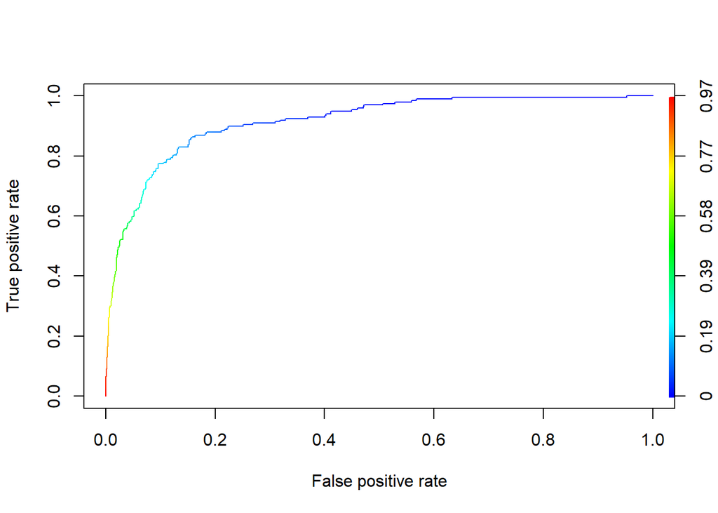

```r
Accuracy1 <- (1357+145)/(1357+120+54+145)
Accuracy1
```

```
## [1] 0.8961814
```

```r
Accuracy2 <- (1366+142)/(1366+111+57+142)
Accuracy2
```

```
## [1] 0.8997613
```

#### **Accuracy with 0.25 cutoff is bit higher than Accuracy with 0.225**